# MyUH 1867424

# Homework Assignment 3

# STEP 1

```python
import pandas as pd
import numpy as np
import matplotlib.pyplot as plt
import matplotlib as plt1
import seaborn as sns
from matplotlib.pyplot import pie, axis, show
%matplotlib inline
import warnings
warnings.filterwarnings("ignore")
import scipy.cluster.hierarchy as sch
from sklearn.cluster import AgglomerativeClustering
import sklearn
from sklearn.cluster import KMeans
from sklearn.metrics import silhouette_score
```

```python
Dosbol=pd.read_csv('data_h3_3337.csv')
```

#### Would we approach this as a supervised or unsupervised supervised task and why?

1. it is an UNsupervised learning task since we are using a clustering algorithm to analyze unlabeled data, and my model is **Hierarchal Clustering**.

```python
Dosbol.head()
```

|  | CustomerID | Gender | Age | Annual Income (k$) | Spending Score (1-100) |
| --- | --- | --- | --- | --- | --- |
| 0 | 1 | Male | 19 | 15 | 39 |
| 1 | 2 | Male | 21 | 15 | 81 |
| 2 | 3 | Female | 20 | 16 | 6 |
| 3 | 4 | Female | 23 | 16 | 77 |
| 4 | 5 | Female | 31 | 17 | 40 |

```python
Dosbol.info()
```

```
<class 'pandas.core.frame.DataFrame'>
RangeIndex: 200 entries, 0 to 199
Data columns (total 5 columns):
 #   Column                  Non-Null Count  Dtype
---  ------                  --------------  -----
 0   CustomerID              200 non-null    int64
 1   Gender                  200 non-null    object
 2   Age                     200 non-null    int64
 3   Annual Income (k$)      200 non-null    int64
 4   Spending Score (1-100)  200 non-null    int64
dtypes: int64(4), object(1)
memory usage: 7.9+ KB
```

```python
Dosbol
```

|  | CustomerID | Gender | Age | Annual Income (k$) | Spending Score (1-100) |
| --- | --- | --- | --- | --- | --- |
| 0 | 1 | Male | 19 | 15 | 39 |
| 1 | 2 | Male | 21 | 15 | 81 |
| 2 | 3 | Female | 20 | 16 | 6 |
| 3 | 4 | Female | 23 | 16 | 77 |
| 4 | 5 | Female | 31 | 17 | 40 |
| ... | ... | ... | ... | ... | ... |
| 195 | 196 | Female | 35 | 120 | 79 |
| 196 | 197 | Female | 45 | 126 | 28 |
| 197 | 198 | Male | 32 | 126 | 74 |
| 198 | 199 | Male | 32 | 137 | 18 |
| 199 | 200 | Male | 30 | 137 | 83 |

200 rows × 5 columns

```python
CustomerID_new = len(Dosbol.CustomerID.unique())
CustomerID_new
```

```
200
```

```python
Gender_new = len(Dosbol.Gender.unique())
Gender_new
```

```
2
```

```python
Age_new = len(Dosbol.Age.unique())
Age_new
```

```
51
```

```python
Annual_Income_new = len(Dosbol['Annual Income (k$)'].unique())
Annual_Income_new
```

```
64
```

```python
Spending_Score_new = len(Dosbol['Spending Score (1-100)'].unique())
Spending_Score_new
```

```
84
```

# STEP 1 Conclusion

#### STEP 1 Questions:

1. How many observations are there in total?  
2. Are there any missing values?  
3. How many unique values are in each column?

#### STEP 1 ANSWERS:

1. There are 200 observations because because we have 200 rows × 5 columns. row=observation  
2. No, We do not have any missing values because every item is 200 non-null  
3. To get Unique values we have to use **.unique() and len() Key Words**  
a. CustomerID -> we have **200 values** because every item is unique  
b. Gender -> We have only **2 unique values** **"MALE and FELAME"**  
c. Age -> **51 unique values**  
d. Annual Income -> **64 unique values**  
e. Spending Score->**84 unique values**

# Step 2 (visualizations) Number 1 (HISTOGRAM)

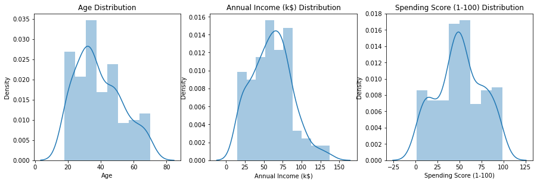

```python
plt.figure(figsize=(15,10))

plt.subplot(2,3,1)
plt.title('Age Distribution')
sns.distplot(Dosbol.Age)

plt.subplot(2,3,2)
plt.title('Annual Income (k$) Distribution')
sns.distplot(Dosbol["Annual Income (k$)"])

plt.subplot(2,3,3)
plt.title('Spending Score (1-100) Distribution')
sns.distplot(Dosbol["Spending Score (1-100)"])


plt.show()
```

#### STEP 1 QUESTION (HISTOGRAMs):

1. What can you conclude from the plots you created? Are there any interesting findings?

#### STEP 1 ANSWER (HISTOGRAM):

# Step 2 (visualizations) Number 2 ( PIE CHART of Age)

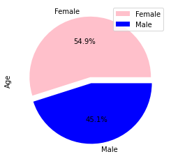

```python
colors = ['pink', 'blue']
explode = (0.05, 0.05)
Dosbol.groupby(['Gender']).sum().plot(
    kind='pie', y='Age', autopct='%01.1f%%',
  colors=colors,explode=explode )

plt.show()
```

#### STEP 1 QUESTION (PIE CHART):

1. What can you conclude from the plot you created?

#### STEP 1 ANSWER:

# Step 2 (visualizations)-> Number 3 (HeatMap)

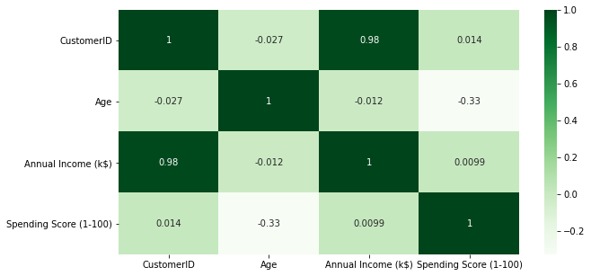

```python
plt.figure(figsize=(10,5))
sns.heatmap(Dosbol.corr(),annot=True,cmap="Greens")
plt.show()
```

#### STEP 2 QUESTION (HeatMap):

1. After creating your heatmap, is there anything interesting? For example, any significant multicollinearity?

#### STEP 2 ANSWER (HEATMAP):

# Step 2 (visualizations) Number 4 scatter plot(X Vs Y)

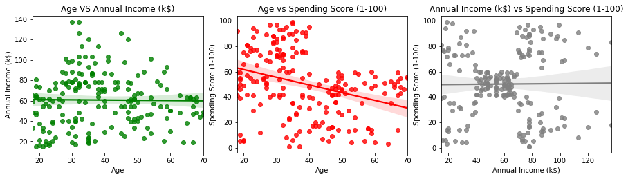

```python
plt.figure(figsize=(15,8))

plt.subplot(2,3,1)
plt.title('Age VS Annual Income (k$)')
sns.regplot(Dosbol['Age'],Dosbol['Annual Income (k$)'],color="green")

plt.subplot(2,3,2)
plt.title('Age vs Spending Score (1-100)')
sns.regplot(Dosbol['Age'],Dosbol['Spending Score (1-100)'],color="red")

plt.subplot(2,3,3)
plt.title('Annual Income (k$) vs Spending Score (1-100)')
sns.regplot(Dosbol['Annual Income (k$)'],Dosbol['Spending Score (1-100)'],color="grey")

plt.show()
```

#### STEP 2 QUESTION (SCATTER PLOT):

1. What can you conclude from the plots you created? Are there any interesting findings?

#### STEP 2 ANSWER (SCATTER PLOT):

1. We can conclude that a. In this first plot, we can see that "A line of best fit " is constant, so it goes straight  
b. "A line of best fit " is decreasing,means that correction is negative c. It is also "A line of best fit " is constant

# Step 2 (visualizations) Number 5 (LINE GRAPH)

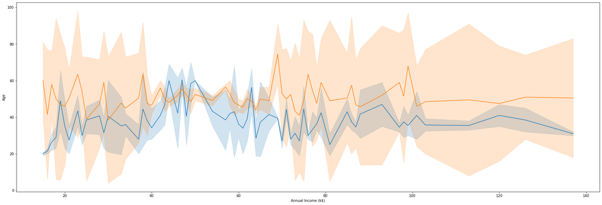

```python
plt.figure(figsize=(30,10))
sns.lineplot(x = Dosbol['Annual Income (k$)'], y = Dosbol['Age'])
sns.lineplot(x = Dosbol['Annual Income (k$)'], y = Dosbol['Spending Score (1-100)'])
plt.show()
```

#### STEP 2 QUESTION (LINE-PLOT):

1. What can you say about the plot you created?

#### STEP 2 ANSWER (LINE-PLOT):

# Step 3 (K-means clustering)

```python
Data1=Dosbol[["Annual Income (k$)","Spending Score (1-100)"]]
```

```python
import sklearn.cluster as cluster
```

```python
K=range(1,12)
wss=[]

for k in K:
    kmeans=cluster.KMeans(n_clusters=k,init='k-means++')
    kmeans=kmeans.fit(Data1)
    wss_iter=kmeans.inertia_
    wss.append(wss_iter)
```

```python
Dosbol1=pd.DataFrame({"Clusters":K,"WSS":wss})
Dosbol1
```

|  | Clusters | WSS |
| --- | --- | --- |
| 0 | 1 | 269981.280000 |
| 1 | 2 | 181363.595960 |
| 2 | 3 | 106348.373062 |
| 3 | 4 | 73679.789039 |
| 4 | 5 | 44448.455448 |
| 5 | 6 | 37239.835542 |
| 6 | 7 | 30259.657207 |
| 7 | 8 | 25043.970950 |
| 8 | 9 | 21829.135639 |
| 9 | 10 | 19646.482019 |
| 10 | 11 | 17862.280588 |

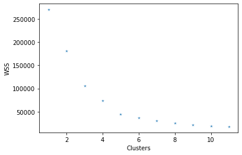

```python
sns.scatterplot(x="Clusters",y="WSS",data=Dosbol1,marker="*")
plt.show()
```

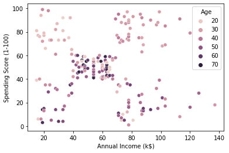

```python
X1 = Dosbol["Spending Score (1-100)"]
X2 = Dosbol["Annual Income (k$)"]
sns.scatterplot(x=X2,y=X1,hue="Age",data=Dosbol)
plt.show()
```

# Step 4 (Hierarchical Clustering)

```python
New_dosbol=Dosbol.iloc[:,3:5].values
```

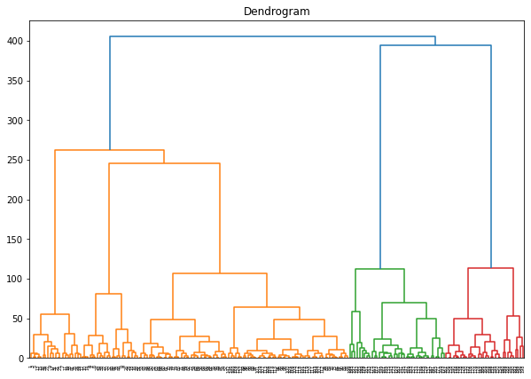

```python
plt.figure(figsize=(10,7))
dendrogram = sch.dendrogram(sch.linkage(New_dosbol,method="ward"))
plt.title("Dendrogram")

plt.show()
```

```python
cluster=AgglomerativeClustering(n_clusters=5,affinity='euclidean',linkage="ward")
cluster.fit_predict(New_dosbol)
```

```
array([4, 3, 4, 3, 4, 3, 4, 3, 4, 3, 4, 3, 4, 3, 4, 3, 4, 3, 4, 3, 4, 3,
       4, 3, 4, 3, 4, 3, 4, 3, 4, 3, 4, 3, 4, 3, 4, 3, 4, 3, 4, 3, 4, 1,
       4, 1, 1, 1, 1, 1, 1, 1, 1, 1, 1, 1, 1, 1, 1, 1, 1, 1, 1, 1, 1, 1,
       1, 1, 1, 1, 1, 1, 1, 1, 1, 1, 1, 1, 1, 1, 1, 1, 1, 1, 1, 1, 1, 1,
       1, 1, 1, 1, 1, 1, 1, 1, 1, 1, 1, 1, 1, 1, 1, 1, 1, 1, 1, 1, 1, 1,
       1, 1, 1, 1, 1, 1, 1, 1, 1, 1, 1, 1, 1, 2, 1, 2, 1, 2, 0, 2, 0, 2,
       1, 2, 0, 2, 0, 2, 0, 2, 0, 2, 1, 2, 0, 2, 1, 2, 0, 2, 0, 2, 0, 2,
       0, 2, 0, 2, 0, 2, 1, 2, 0, 2, 0, 2, 0, 2, 0, 2, 0, 2, 0, 2, 0, 2,
       0, 2, 0, 2, 0, 2, 0, 2, 0, 2, 0, 2, 0, 2, 0, 2, 0, 2, 0, 2, 0, 2,
       0, 2], dtype=int64)
```

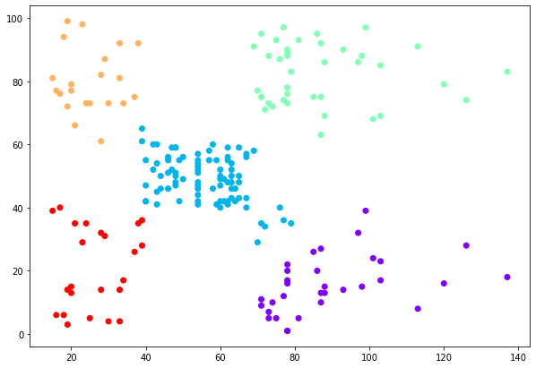

```python
plt.figure(figsize=(10,7))
plt.scatter(New_dosbol[:,0],New_dosbol[:,1],c= cluster.labels_,cmap="rainbow")
plt.show()
```

# STEP 5 (conclusion)

#### CONCLUSION

Write a brief conclusion summarizing your results and how K-Means and Hierarchical clustering differed.

#### The brief conclusion summarizing

K Means clustering can handle large amounts of data better than hierarchical clustering.  
In K means clustering, we must first determine the number of clusters to be produced, which might be challenging to decide. Unlike hierarchical clustering, which automatically forms data into a tree shape form (dendrogram), we can select which trees are relevant.

#### QUESTIONS

1. Briefly explain how both k-means and hierarchical clustering work along with their advantages/disadvantages if any  
2. Give an example of where you could use hierarchical clustering or k-means

The most fundamental difference is where to use K means and Hierarchical clustering based on Scalability and Flexibility. Hierarchical is Flexible but can not be used on extensive data. K means is scalable but cannot use for flexible data. It would be best not to use hierarchical clustering for large datasets, and Hierarchical clustering is generally applicable to a small data set. When dealing with massive data sets, K means is quite beneficial. On the other hand, the K means is exclusively relevant to numeric data. When it comes to variety, hierarchical clustering is the apparent victor. It doesn't even have to be a distance; any measure, including similarity functions, may be employed simply by preferring high to low values.

```python
pd.to_numeric(DATASET["X"],errors='coerce').notnull().all()
```

[output not shown]